# Processos Estocásticos (Online)

Lucas Bicalho

03/09/2020

## Passeio Aleatório Simples

Espaço de estados discreto a tempo discreto

```r
#p(x=1)=p e p(x=-1)=1-p
p <- 0.5
q <- 1-p
n <- 1000
x <- ifelse(purrr::rbernoulli(n = n, p = p) == TRUE, 1, -1)
head(x, 10)
```

```
##  [1]  1 -1  1  1 -1  1 -1  1  1  1
```

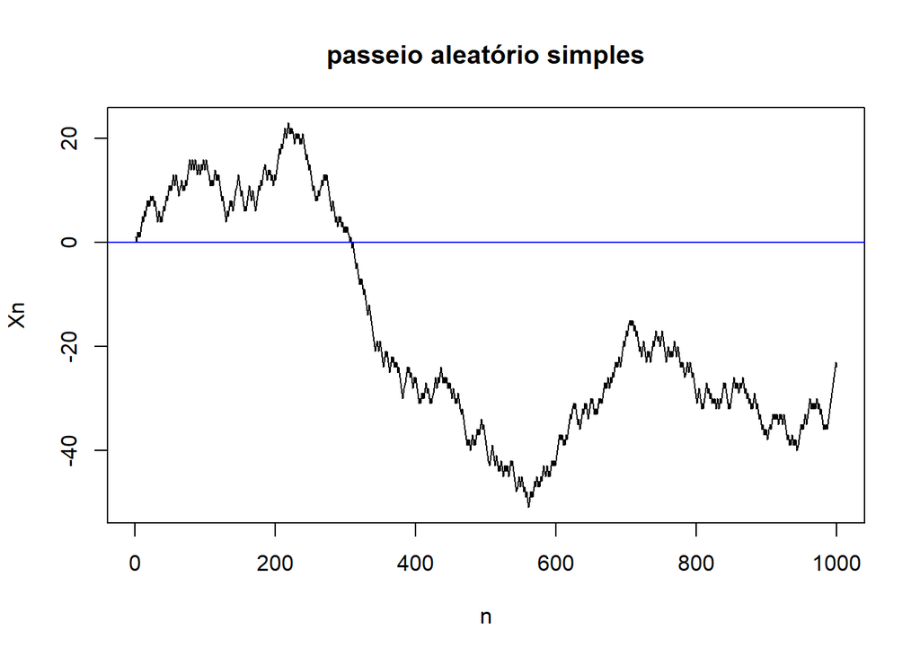

```r
#{Sn, n>=0} = X1+ X2 + ... + Xn
# E = inteiros
# T = {0, 1, 2, ...}
sn <- cumsum(x)
plot(sn, type = "l", main = "passeio aleatório simples", ylab = "Xn", xlab = "n")
abline(h=0, col = 4)
```

# Processo de Contagem

Espaço de estado discreto a tempo discreto ou tempo contínuo

```r
#{Xt, t>=0}
# X0 = 0
# Xt >= 0
# Xt é valor inteiro
# Xs <= Xt se s < t
# Xt - Xs = n° de ocorrências em (s,t]
```

# Processo de Bernoulli

$\{X_n\}_{n\geq1}$ processo a tempo discreto tal que as variáveis aleatórias $X_i$ são i.i.d. com $P(X_n=1)=p$ e $P(X_n=0)=1-p$ é chamado processo de Bernoulli com parâmetro p.

Para cada realização do processo o valor é TRUE ou FALSE.

```r
p <- 0.5
n <- 1000
x <- purrr::rbernoulli(n = n, p = p)
head(x, 10)
```

```
##  [1]  TRUE FALSE  TRUE  TRUE  TRUE  TRUE  TRUE FALSE  TRUE FALSE
```

```r
mean(x)
```

```
## [1] 0.496
```

```r
var(x)
```

```
## [1] 0.2502342
```

```r
p*(1-p)
```

```
## [1] 0.25
```

Vamos observar como se comportam a média e variância no decorrer dos ensaios

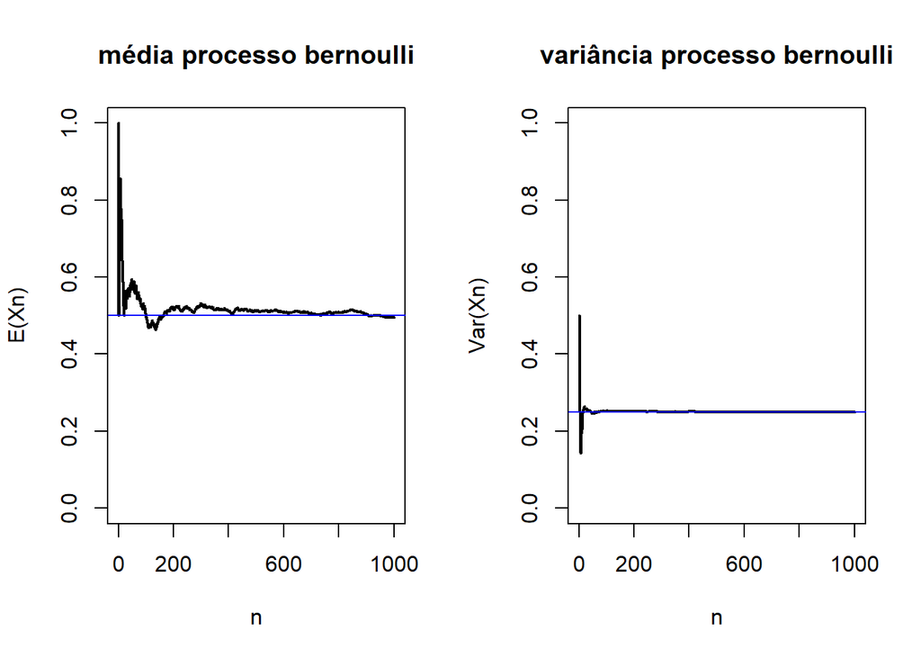

```r
mean_x <- c()
var_x <- c()

for(i in 1:n){
  mean_x[i] <- mean(x[1:i])
  var_x[i] <- var(x[1:i])
}

par(mfrow = c(1,2))
plot(mean_x, type = "l", main = "média processo bernoulli", xlab = "n", ylab = "E(Xn)", ylim = c(0,1), lwd = 2)
abline(h=p, col = 4)

plot(var_x, type = "l", main = "variância processo bernoulli", xlab = "n", ylab = "Var(Xn)", ylim = c(0,1), lwd = 2)
abline(h=p*(1-p), col = 4)
```

```r
par(mfrow = c(1,1))
```

# Processo Binomial

Se definirmos $\{S_n\}_{n\geq1}$ como $S_n = \sum_{i=1}^{n} X_i$, $i=1,\ldots,n$ com $n\geq1$, temos que

-$S_n \sim Bin(n,p)$

-$E(S_n) = np$

-$Var(S_n) = np(1-p)$

A Lei Forte dos Grandes Números diz que $S_n/n$ converge quase certamente para $p$. Onde $S_n/n \in [p-\epsilon; p+\epsilon]$

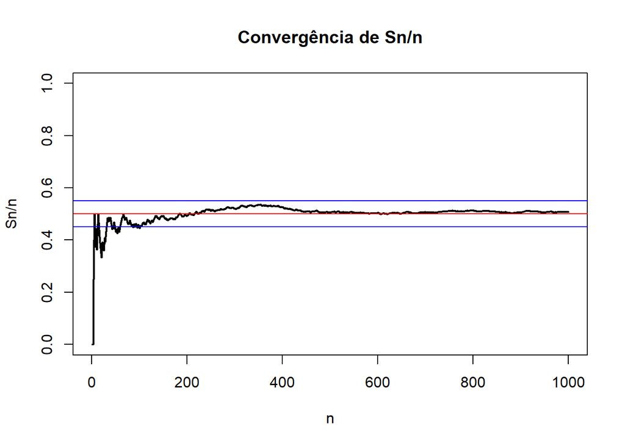

```r
p <- 0.5
n <- 1000
e <- 0.05
x <- purrr::rbernoulli(n = n, p = p)
x <- cumsum(x)
s <- 1:n
s <- x/s

plot(s, type = "l", main = "Convergência de Sn/n", xlab = "n", ylab = "Sn/n", ylim = c(0,1), lwd = 2)
abline(h=p-e, col = 4)
abline(h=p+e, col = 4)
abline(h=p, col = 2)
```

# Processo de Chegadas

Seja $\{X_n\}_{n\geq1}$ o processo de Bernoulli com parâmetro $p$. Para $n\geq1$ defina $T_n$ como o instante do n-ésimo sucesso.

$\{T_n\}_{n\geq1}$ é chamado processo de chegadas.

## Processo entre chegadas

Seja $W_n = T_n - T_{n-1}$. $W_n$ é o tempo entre o (n-1)-ésimo e o n-ésimo sucesso.

O processo $\{W_n\}_{n\geq1}$ é chamado processo entre chegadas.

### Teorema

- $T_n \sim Pascal(n,p)$
  - $E(T_n) = \frac{n}{p}$
  - $Var(T_n) = \frac{n(1-p)}{p^2}$
- $W_n \sim Geométrica(p)$
  - $E(W_n) = \frac{1}{p}$
  - $Var(W_n) = \frac{1-p}{p^2}$

Distribuição Pascal (Binomial negativa): número de tentativas necessárias para obter $k$ sucessos ao fim de $n$ ensaios de $Bernoulli(p)$.

Distribuição Geométrica: número de tentativas necessárias para atingir o primeiro sucesso.

### Lei Forte dos Grandes Números

$\frac{T_n}{n}$ converge quase que certamente para $\frac{1}{p}$ Note que $\frac{T_n}{n} = \sum_{i=1}^{n} \frac{w_i}{n}$

```r
p <- 0.5
n <- 10000
e <- 0.5
x <- purrr::rbernoulli(n = n, p = p)
t <- c()
k <- 1
for(i in 1:n){
  # t é o instante do i-ésimo sucesso
  if(x[i]==TRUE){
    t[k] <- i
    k <- k + 1
  }
}

head(t,10)
```

```
##  [1]  1  2  4  5  7  9 12 17 18 23
```

Ou seja, precisou-se de 23 ensaios de Bernoulli para obter-se o 10º sucesso.

Para $p=0.5$ temos $\frac{1}{p} = \frac{1}{0.5} = 2$.

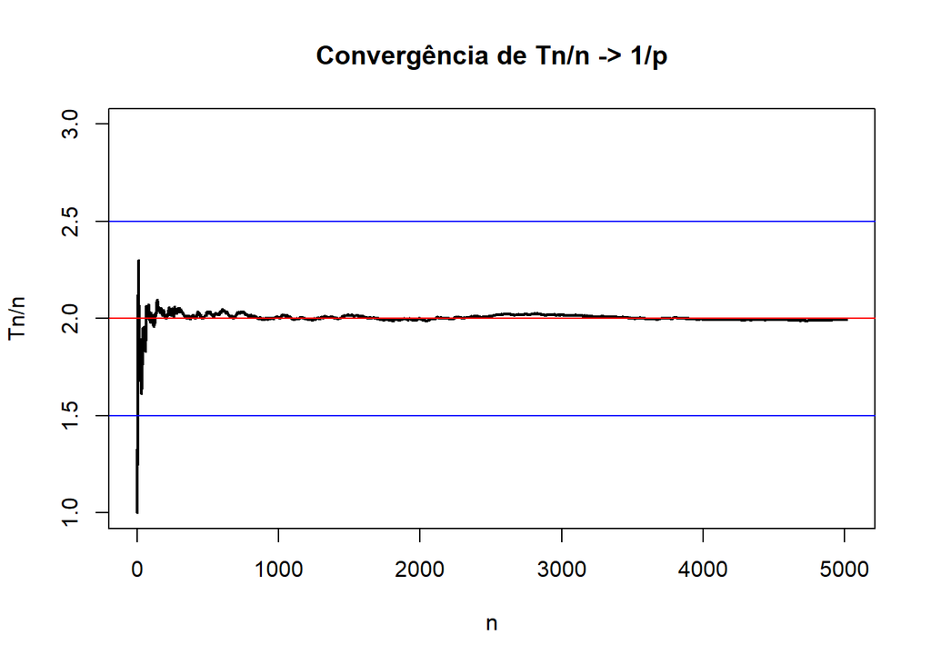

```r
tt <- 1:length(t)
tt <- t/tt

plot(tt, type = "l", main = "Convergência de Tn/n -> 1/p", xlab = "n", ylab = "Tn/n", lwd = 2, ylim = c((1/p)-1, (1/p)+1))
abline(h=(1/p)-e, col = 4)
abline(h=(1/p)+e, col = 4)
abline(h=1/p, col = 2)
```